# 5205 final project Q2 h2

2023-04-25

```r
setwd("C:/Users/Roger/Desktop")
library(tidyverse)
library(tm)
library(tidytext)
library(grid)
library(gridExtra)
library(magrittr)
library(stringr)
library(tidytext); library(magrittr)
disneyland<- read_csv(file = "disneyland.csv")
```

# Research Question 2

## Hypothesis 1:

Ho: Hong Kong Disneyland receives reviews related to shopping experiences in the same proportion as other branches.

Ha: Hong Kong Disneyland receives more reviews related to shopping experiences than other branches.

```r
# examine branch names
unique(disneyland$Branch)
```

```
## [1] "Disneyland_HongKong"   "Disneyland_California" "Disneyland_Paris"
```

Split dataset based on branch

```r
hongkong <- disneyland %>%
  filter(Branch == 'Disneyland_HongKong')
cali <- disneyland %>%
  filter(Branch == 'Disneyland_California')
paris <- disneyland %>%
  filter(Branch == 'Disneyland_Paris')
```

Check document integrity

```r
nrow(disneyland) == nrow(hongkong) + nrow(cali) + nrow(paris)
```

```
## [1] TRUE
```

Create corpus based on branches:

```r
corpus_hk = Corpus(VectorSource(hongkong$Review_Text))
corpus_cali = Corpus(VectorSource(cali$Review_Text))
corpus_paris = Corpus(VectorSource(paris$Review_Text))
```

### Hong Kong

Define shopping-related words:

```r
shopping_words <- c(
  'shop',
  'souvenir',
  'merchandise',
  'collectible',
  'gift',
  'shirt',
  'toy',
  'book',
  'hat',
  'band',
  'art', 'mall', 'cashier', 'cloth', 'checkout', 'cart', 'outlet', 'bag', 'quality', 'boutique'
)
```

Cleaning texts:

```r
corpus <- corpus_hk
# convert to lower cases
corpus = tm_map(corpus,FUN = content_transformer(tolower))
# remove punctuations
corpus = tm_map(corpus,FUN = removePunctuation)
# remove stopwords
corpus = tm_map(corpus,FUN = removeWords,c(stopwords('english')))
# stripwhitespaces
corpus = tm_map(corpus,FUN = stripWhitespace)
# stem the corpurs
corpus = tm_map(corpus,FUN = stemDocument)
# convert corpus to document term matrix to get a list of unique words contained in all reviews
dtm_hk <- DocumentTermMatrix(corpus)
# select words unrelated to shopping to be removed
words_remove <- setdiff(colnames(dtm_hk), shopping_words)
length(words_remove)
```

```
## [1] 17979
```

```r
# remove words unrelated to shopping
corpus = tm_map(corpus, FUN = removeWords, words_remove[1:4000])
corpus = tm_map(corpus, FUN = removeWords, words_remove[4001:7000])
corpus = tm_map(corpus, FUN = removeWords, words_remove[7001:10000])
corpus = tm_map(corpus, FUN = removeWords, words_remove[10001:13000])
corpus = tm_map(corpus, FUN = removeWords, words_remove[13001:16000])
corpus = tm_map(corpus, FUN = removeWords, words_remove[16001:17987])
corpus = tm_map(corpus, FUN = removeNumbers)
```

Transform cleaned corpus to document term matrix

```r
dtm_hk_then <- DocumentTermMatrix(corpus)
colnames(dtm_hk_then)
```

```
##  [1] "gift"     "shop"     "souvenir" "book"     "toy"      "cloth"
##  [7] "hat"      "outlet"   "bag"      "mall"     "cart"     "cashier"
## [13] "shirt"    "art"      "band"     "checkout"
```

Make data frame

```r
dtm_hk_then = as.data.frame(as.matrix(dtm_hk_then))
sort(colSums(dtm_hk_then),decreasing = T)
```

```
##     shop      toy     book souvenir      bag     gift   outlet     cart
##      860      738      416      400      194      133      107       78
##      hat    cloth    shirt      art     band     mall  cashier checkout
##       76       68       48       24       19       18       16        1
```

Add information summarizing columns:

```r
# add a column counting the number of shopping related words in a review
dtm_hk_then['shopping_word_count'] = rowSums(dtm_hk_then)
# add a column specifying if a review contains shopping related words
dtm_hk_then['if_shopping_word'] = ifelse(dtm_hk_then$shopping_word_count >= 1, 1, 0)
```

Attach word frequency to original data frame and select columns

```r
hongkong <- hongkong %>%
  cbind(dtm_hk_then) %>%
  select(-Review_ID, -Reviewer_Location,
         -Review_Text, -Year_Month,
         -Year, -Month, -continent)
hongkong['no_shopping_word'] = ifelse(rowSums(hongkong[4:19]) == 0, 1, 0)
hongkong <- hongkong %>%
  select_if(function(x) !all(x == 0))
```

Calculate average ratings for each shopping words and add counts

```r
shopping_hk = data.frame(rd=names(colSums(hongkong[c(4:22)])))
df <- data.frame()
for (i in 1:nrow(shopping_hk)) {
  for (k in shopping_hk[i,]) {
    avg_rating <- hongkong %>%
      filter(hongkong[,k] != 0) %>%
      summarise(avg_rating = mean(Rating))
    df <- rbind(df, avg_rating)
  }
}
shopping_mention_count <- data.frame(rides = names(colSums(hongkong[c(4:22)])),
                                 counts = as.numeric(colSums(hongkong[c(4:22)])),
                                 avg_raing = df)
shopping_mention_count
```

```
##                  rides counts avg_rating
## 1                 gift    133   4.237705
## 2                 shop    860   4.196906
## 3             souvenir    400   4.185792
## 4                 book    416   4.385445
## 5                  toy    738   4.297638
## 6                cloth     68   4.348485
## 7                  hat     76   4.027397
## 8               outlet    107   3.970588
## 9                  bag    194   4.075949
## 10                mall     18   4.000000
## 11                cart     78   4.144928
## 12             cashier     16   3.545455
## 13               shirt     48   4.066667
## 14                 art     24   4.523810
## 15                band     19   4.277778
## 16            checkout      1   4.000000
## 17 shopping_word_count   3196   4.241515
## 18    if_shopping_word   2033   4.241515
## 19    no_shopping_word   7114   4.208040
```

Get frequency of each shopping word in total branch reviews & in reviews that mentioned shopping in the branch

```r
freq_all <- shopping_mention_count %>%
  mutate(freq_branch_pct = counts/nrow(hongkong)*100,
         freq_Mention_pct = counts/counts[17]*100) %>%
  mutate_at(c(3:5), round, digits = 2)%>%
  arrange(desc(freq_Mention_pct))
freq_all
```

```
##                  rides counts avg_rating freq_branch_pct freq_Mention_pct
## 1     no_shopping_word   7114       4.21           77.77           222.59
## 2  shopping_word_count   3196       4.24           34.94           100.00
## 3     if_shopping_word   2033       4.24           22.23            63.61
## 4                 shop    860       4.20            9.40            26.91
## 5                  toy    738       4.30            8.07            23.09
## 6                 book    416       4.39            4.55            13.02
## 7             souvenir    400       4.19            4.37            12.52
## 8                  bag    194       4.08            2.12             6.07
## 9                 gift    133       4.24            1.45             4.16
## 10              outlet    107       3.97            1.17             3.35
## 11                cart     78       4.14            0.85             2.44
## 12                 hat     76       4.03            0.83             2.38
## 13               cloth     68       4.35            0.74             2.13
## 14               shirt     48       4.07            0.52             1.50
## 15                 art     24       4.52            0.26             0.75
## 16                band     19       4.28            0.21             0.59
## 17                mall     18       4.00            0.20             0.56
## 18             cashier     16       3.55            0.17             0.50
## 19            checkout      1       4.00            0.01             0.03
```

#### Rating analysis

Proportions of reviews that mentioned shopping words & no mention rides in the branch

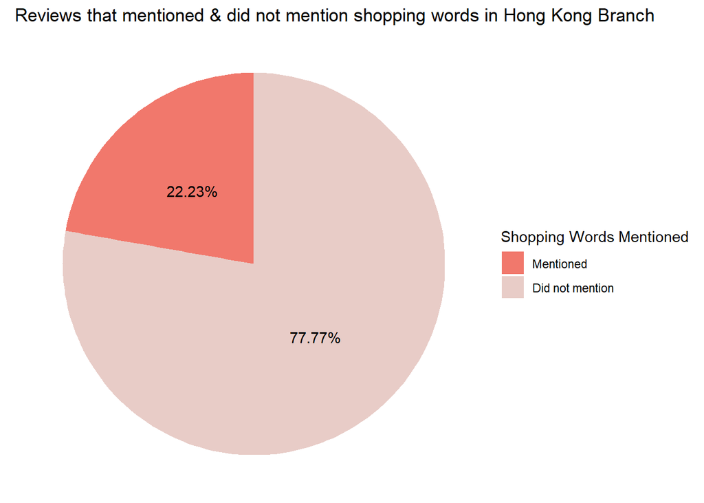

```r
p_mention_orno <- freq_all[c(1,3), 1:4]
p_mention_orno%>%
  ggplot(aes(x="", y=freq_branch_pct, fill=rides)) +
  geom_bar(stat="identity", width=1) +
  coord_polar("y", start=0) +
  labs(fill = "Shopping Words Mentioned") +
  ggtitle("Reviews that mentioned & did not mention shopping words in Hong Kong Branch") +
  theme_void()+
  geom_text(aes(label = paste0(freq_branch_pct, "%")), position = position_stack(vjust=0.5)) +
  scale_fill_manual(values=c("#F1786C", "#E8CCC7"),
                    labels=c("Mentioned", "Did not mention"))
```

Proportions of shopping words mentioned in the branch over total number of reviews in the branch & over reviews that mentioned rides in branch

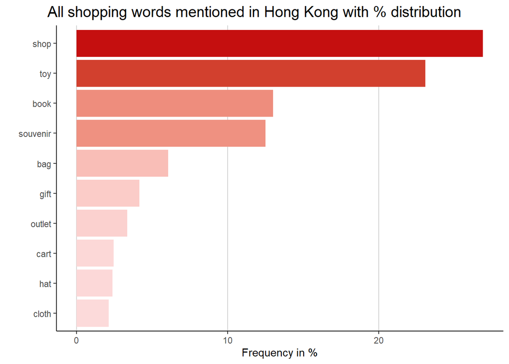

```r
p_shops <- freq_all[4:19, 1:5]

# filter freqs >= 2% of the reviews that mentioned rides in the branch, rating high to low
hot_shops <- p_shops %>%
  filter(freq_Mention_pct >= 2)

shopping_rank_plot <- hot_shops%>%
  ggplot(aes(x=reorder(rides,freq_Mention_pct),
             y=freq_Mention_pct, fill=freq_Mention_pct))+
  geom_col(position='dodge')+
  coord_flip()+
  labs(x = "", y = "Frequency in %") +
  ggtitle("All shopping words mentioned in Hong Kong with % distribution")+
  scale_fill_gradient(low = "#FCDADA", high = "#C50F0F", guide = FALSE) +
  theme(plot.background = element_blank(),
        panel.background = element_blank(),
        panel.grid.major.x  = element_line(color = "light grey"),
        axis.line = element_line(color = "black"),
        plot.title = element_text(size = 15, hjust = -0.267, vjust = 1))

rating_rank_plot <- hot_shops %>%
  ggplot() +
  geom_col(aes(x=reorder(rides, -avg_rating), y=freq_Mention_pct, fill=freq_Mention_pct),
           width=0.7, position='dodge')+
  scale_y_continuous(name = "Frequency in %",
                     expand = c(0,0),
                     limits = c(-10, 80)) +
  geom_text(aes(x=rides, y=-5, label=avg_rating), size = 4.5) +
  labs(x = "Mostly mentioned shopping words", y = "Frequency in %") +
  ggtitle("Average rating ranked with most popular shopping words & no shopping words") +
  scale_fill_gradient(low = "#FCDADA", high = "#C50F0F", guide = FALSE)+
  labs(tag ="Ratings:")+
  theme(plot.background = element_blank(),
        panel.background = element_blank(),
        panel.grid.major.y  = element_line(color = "light grey"),
        axis.line = element_line(color = "black"),
        plot.tag.position = c(0.01,0.115),
        plot.tag = element_text(hjust = 0, size=12.5),
        plot.title = element_text(size = 15))

#grid.arrange(shopping_rank_plot, rating_rank_plot, ncol = 2)
shopping_rank_plot
```

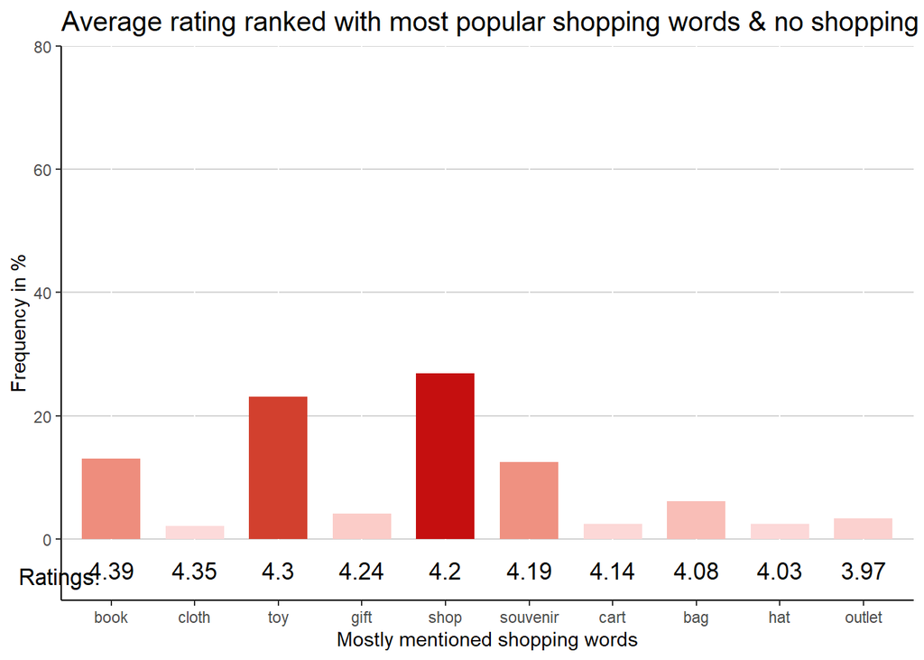

```r
rating_rank_plot
```

From the two graphs above, we can see that words including “shop”, “toy”, “book” and “souvenir” are mentioned most frequently in reviews of the Hong Kong brancn, indicating the most cared aspects of shopping. Products like book, cloth and toy received higher ratings while cart, bag hat received lower ratings also implies customer satisfaction.

### California

Cleaning texts:

```r
corpus <- corpus_cali
corpus = tm_map(corpus,FUN = content_transformer(tolower))
corpus = tm_map(corpus,FUN = removePunctuation)
corpus = tm_map(corpus,FUN = removeWords,c(stopwords('english')))
corpus = tm_map(corpus,FUN = stripWhitespace)
corpus = tm_map(corpus,FUN = stemDocument)
dtm_cali <- DocumentTermMatrix(corpus)
words_remove <- setdiff(colnames(dtm_cali), shopping_words)
length(words_remove)
```

```
## [1] 25632
```

```r
corpus = tm_map(corpus, FUN = removeWords, words_remove[1:4000])
corpus = tm_map(corpus, FUN = removeWords, words_remove[4001:7000])
corpus = tm_map(corpus, FUN = removeWords, words_remove[7001:10000])
corpus = tm_map(corpus, FUN = removeWords, words_remove[10001:13000])
corpus = tm_map(corpus, FUN = removeWords, words_remove[13001:16000])
corpus = tm_map(corpus, FUN = removeWords, words_remove[16001:19000])
corpus = tm_map(corpus, FUN = removeWords, words_remove[19001:21000])
corpus = tm_map(corpus, FUN = removeWords, words_remove[21001:24000])
corpus = tm_map(corpus, FUN = removeWords, words_remove[24001:25632])
corpus = tm_map(corpus, FUN = removeNumbers)
```

Transform cleaned corpus to document term matrix

```r
dtm_cali_then <- DocumentTermMatrix(corpus)
colnames(dtm_cali_then)
```

```
##  [1] "book"     "bag"      "shop"     "gift"     "cloth"    "band"
##  [7] "cart"     "shirt"    "souvenir" "art"      "toy"      "hat"
## [13] "outlet"   "cashier"  "mall"     "checkout"
```

Make data frame

```r
dtm_cali_then = as.data.frame(as.matrix(dtm_cali_then))
sort(colSums(dtm_cali_then),decreasing = T)
```

```
##     shop     book      bag souvenir      toy     gift      hat     band
##      864      777      392      308      189      173      168      139
##    cloth     cart    shirt      art   outlet  cashier     mall checkout
##      123      123       98       87       53       21       16        4
```

Add information summarizing columns:

```r
# add a column counting the number of shopping related words in a review
dtm_cali_then['shopping_word_count'] = rowSums(dtm_cali_then)
# add a column specifying if a review contains shopping related words
dtm_cali_then['if_shopping_word'] = ifelse(dtm_cali_then$shopping_word_count >= 1, 1, 0)
```

Attach word frequency to original data frame and select columns

```r
cali <- cali %>%
  cbind(dtm_cali_then) %>%
  select(-Review_ID, -Reviewer_Location,
         -Review_Text, -Year_Month,
         -Year, -Month, -continent)
cali['no_shopping_word'] = ifelse(rowSums(cali[4:19]) == 0, 1, 0)
cali <- cali %>%
  select_if(function(x) !all(x == 0))
```

Calculate average ratings for each shopping words and add counts

```r
shopping_ca = data.frame(rd=names(colSums(cali[c(4:22)])))
# average rating for each shopping word
df <- data.frame()
for (i in 1:nrow(shopping_ca)) {
  for (k in shopping_ca[i,]) {
    avg_rating <- cali %>%
      filter(cali[,k] != 0) %>%
      summarise(avg_rating = mean(Rating))
    df <- rbind(df, avg_rating)
  }
}
# shopping words, counts, and average ratings
shopping_mention_count <- data.frame(rides = names(colSums(cali[c(4:22)])),
                                     counts = as.numeric(colSums(cali[c(4:22)])),
                                     avg_raing = df)
shopping_mention_count
```

```
##                  rides counts avg_rating
## 1                 book    777   4.286441
## 2                  bag    392   4.003247
## 3                 shop    864   4.410397
## 4                 gift    173   4.416667
## 5                cloth    123   4.385965
## 6                 band    139   4.413223
## 7                 cart    123   4.037383
## 8                shirt     98   4.116279
## 9             souvenir    308   4.117438
## 10                 art     87   4.535211
## 11                 toy    189   4.260606
## 12                 hat    168   4.493151
## 13              outlet     53   4.060000
## 14             cashier     21   3.684211
## 15                mall     16   3.937500
## 16            checkout      4   4.500000
## 17 shopping_word_count   3535   4.267581
## 18    if_shopping_word   2332   4.267581
## 19    no_shopping_word  15870   4.435161
```

Get frequency of each shopping word in total branch reviews & in reviews that mentioned shopping in the branch

```r
freq_all <- shopping_mention_count %>%
  mutate(freq_branch_pct = counts/nrow(cali)*100,
         freq_Mention_pct = counts/counts[17]*100) %>%
  mutate_at(c(3:5), round, digits = 2)%>%
  arrange(desc(freq_Mention_pct))
freq_all
```

```
##                  rides counts avg_rating freq_branch_pct freq_Mention_pct
## 1     no_shopping_word  15870       4.44           87.19           448.94
## 2  shopping_word_count   3535       4.27           19.42           100.00
## 3     if_shopping_word   2332       4.27           12.81            65.97
## 4                 shop    864       4.41            4.75            24.44
## 5                 book    777       4.29            4.27            21.98
## 6                  bag    392       4.00            2.15            11.09
## 7             souvenir    308       4.12            1.69             8.71
## 8                  toy    189       4.26            1.04             5.35
## 9                 gift    173       4.42            0.95             4.89
## 10                 hat    168       4.49            0.92             4.75
## 11                band    139       4.41            0.76             3.93
## 12               cloth    123       4.39            0.68             3.48
## 13                cart    123       4.04            0.68             3.48
## 14               shirt     98       4.12            0.54             2.77
## 15                 art     87       4.54            0.48             2.46
## 16              outlet     53       4.06            0.29             1.50
## 17             cashier     21       3.68            0.12             0.59
## 18                mall     16       3.94            0.09             0.45
## 19            checkout      4       4.50            0.02             0.11
```

#### Rating Analysis

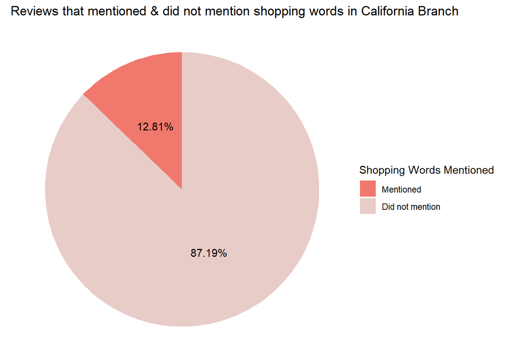

```r
p_mention_orno <- freq_all[c(1,3), 1:4]
p_mention_orno%>%
  ggplot(aes(x="", y=freq_branch_pct, fill=rides)) +
  geom_bar(stat="identity", width=1) +
  coord_polar("y", start=0) +
  labs(fill = "Shopping Words Mentioned") +
  ggtitle("Reviews that mentioned & did not mention shopping words in California Branch") +
  theme_void()+
  geom_text(aes(label = paste0(freq_branch_pct, "%")), position = position_stack(vjust=0.5)) +
  scale_fill_manual(values=c("#F1786C", "#E8CCC7"),
                    labels=c("Mentioned", "Did not mention"))
```

Proportions of shopping words mentioned in the branch over total number of reviews in the branch & over reviews that mentioned rides in branch

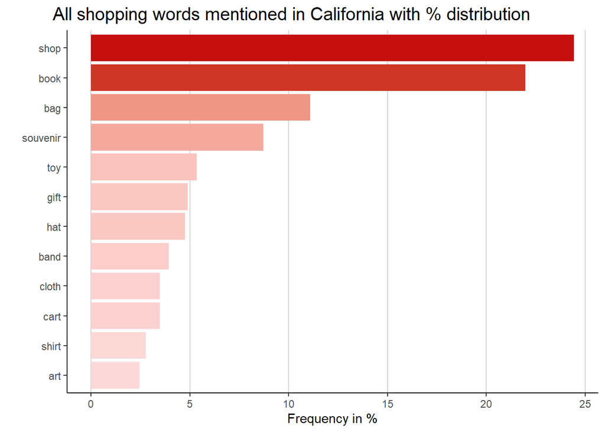

```r
p_shops <- freq_all[4:19, 1:5]

# filter freqs >= 2% of the reviews that mentioned rides in the branch, rating high to low
hot_shops <- p_shops %>%
  filter(freq_Mention_pct >= 2)

shopping_rank_plot <- hot_shops%>%
  ggplot(aes(x=reorder(rides,freq_Mention_pct),
             y=freq_Mention_pct, fill=freq_Mention_pct))+
  geom_col(position='dodge')+
  coord_flip()+
  labs(x = "", y = "Frequency in %") +
  ggtitle("All shopping words mentioned in California with % distribution")+
  scale_fill_gradient(low = "#FCDADA", high = "#C50F0F", guide = FALSE) +
  theme(plot.background = element_blank(),
        panel.background = element_blank(),
        panel.grid.major.x  = element_line(color = "light grey"),
        axis.line = element_line(color = "black"),
        plot.title = element_text(size = 15, hjust = -0.267, vjust = 1))

rating_rank_plot <- hot_shops %>%
  ggplot() +
  geom_col(aes(x=reorder(rides, -avg_rating), y=freq_Mention_pct, fill=freq_Mention_pct),
           width=0.7, position='dodge')+
  scale_y_continuous(name = "Frequency in %",
                     expand = c(0,0),
                     limits = c(-10, 80)) +
  geom_text(aes(x=rides, y=-5, label=avg_rating), size = 4.5) +
  labs(x = "Mostly mentioned shopping words", y = "Frequency in %") +
  ggtitle("Average rating ranked with most popular shopping words & no shopping words") +
  scale_fill_gradient(low = "#FCDADA", high = "#C50F0F", guide = FALSE)+
  labs(tag ="Ratings:")+
  theme(plot.background = element_blank(),
        panel.background = element_blank(),
        panel.grid.major.y  = element_line(color = "light grey"),
        axis.line = element_line(color = "black"),
        plot.tag.position = c(0.01,0.115),
        plot.tag = element_text(hjust = 0, size=12.5),
        plot.title = element_text(size = 15))

#grid.arrange(shopping_rank_plot, rating_rank_plot, ncol = 2)
shopping_rank_plot
```

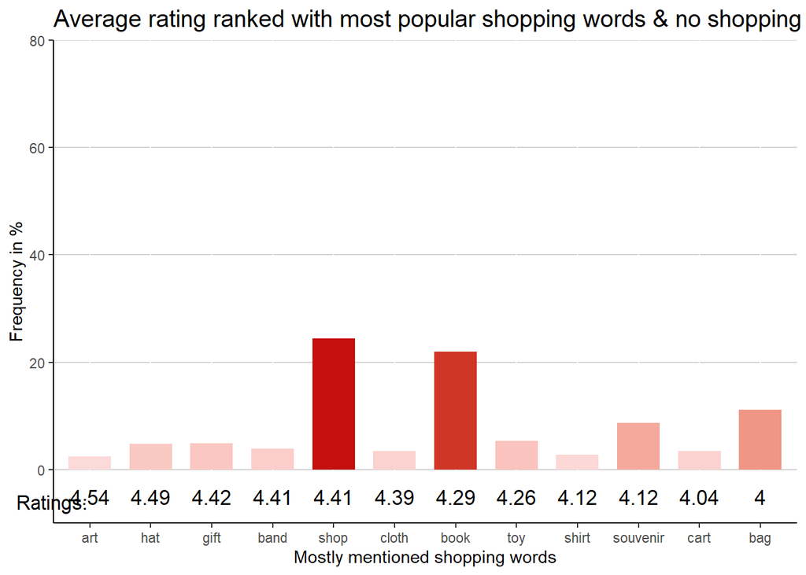

```r
rating_rank_plot
```

### Paris

Cleaning texts:

```r
corpus <- corpus_paris
corpus = tm_map(corpus,FUN = content_transformer(tolower))
corpus = tm_map(corpus,FUN = removePunctuation)
corpus = tm_map(corpus,FUN = removeWords,c(stopwords('english')))
corpus = tm_map(corpus,FUN = stripWhitespace)
#dict = findFreqTerms(DocumentTermMatrix(Corpus(VectorSource(disneyland$Review_Text))),
#                     lowfreq = 0)
#dict_corpus = Corpus(VectorSource(dict))
corpus = tm_map(corpus,FUN = stemDocument)
dtm_hk <- DocumentTermMatrix(corpus)
words_remove <- setdiff(colnames(dtm_hk), shopping_words)
length(words_remove)
```

```
## [1] 32589
```

```r
corpus = tm_map(corpus, FUN = removeWords, words_remove[1:4000])
corpus = tm_map(corpus, FUN = removeWords, words_remove[4001:7000])
corpus = tm_map(corpus, FUN = removeWords, words_remove[7001:10000])
corpus = tm_map(corpus, FUN = removeWords, words_remove[10001:13000])
corpus = tm_map(corpus, FUN = removeWords, words_remove[13001:16000])
corpus = tm_map(corpus, FUN = removeWords, words_remove[16001:19000])
corpus = tm_map(corpus, FUN = removeWords, words_remove[19001:21000])
corpus = tm_map(corpus, FUN = removeWords, words_remove[21001:24000])
corpus = tm_map(corpus, FUN = removeWords, words_remove[24001:27000])
corpus = tm_map(corpus, FUN = removeWords, words_remove[27001:30000])
corpus = tm_map(corpus, FUN = removeWords, words_remove[30001:32589])
corpus = tm_map(corpus, FUN = removeNumbers)
```

Transform cleaned corpus to document term matrix

```r
dtm_paris_then <- DocumentTermMatrix(corpus)
colnames(dtm_paris_then)
```

```
##  [1] "outlet"   "book"     "shop"     "hat"      "gift"     "cart"
##  [7] "souvenir" "shirt"    "toy"      "mall"     "bag"      "band"
## [13] "cloth"    "cashier"  "art"      "checkout"
```

Make data frame

```r
dtm_paris_then = as.data.frame(as.matrix(dtm_paris_then))
sort(colSums(dtm_paris_then),decreasing = T)
```

```
##     book     shop      bag      toy souvenir   outlet     gift      hat
##     2299     2042      579      340      298      259      243      128
##    cloth     cart     band    shirt     mall  cashier      art checkout
##      124      103       67       53       49       44       41        8
```

Add information summarizing columns:

```r
# add a column counting the number of shopping related words in a review
dtm_paris_then['shopping_word_count'] = rowSums(dtm_paris_then)
# add a column specifying if a review contains shopping related words
dtm_paris_then['if_shopping_word'] = ifelse(dtm_paris_then$shopping_word_count >= 1, 1, 0)
```

Attach word frequency to original data frame and select columns

```r
paris <- paris %>%
  cbind(dtm_paris_then) %>%
  select(-Review_ID, -Reviewer_Location,
         -Review_Text, -Year_Month,
         -Year, -Month, -continent)
paris['no_shopping_word'] = ifelse(rowSums(paris[4:19]) == 0, 1, 0)
paris <- paris %>%
  select_if(function(x) !all(x == 0))
```

Calculate average ratings for each shopping words and add counts

```r
shopping_paris = data.frame(rd=names(colSums(paris[c(4:22)])))
# average rating for each shopping word
df <- data.frame()
for (i in 1:nrow(shopping_paris)) {
  for (k in shopping_paris[i,]) {
    avg_rating <- paris %>%
      filter(paris[,k] != 0) %>%
      summarise(avg_rating = mean(Rating))
    df <- rbind(df, avg_rating)
  }
}
# shopping words, counts, and average ratings
shopping_mention_count <- data.frame(rides = names(colSums(paris[c(4:22)])),
                                     counts = as.numeric(colSums(paris[c(4:22)])),
                                     avg_raing = df)
shopping_mention_count
```

```
##                  rides counts avg_rating
## 1               outlet    259   3.530172
## 2                 book   2299   3.844173
## 3                 shop   2042   3.903348
## 4                  hat    128   4.061947
## 5                 gift    243   3.905830
## 6                 cart    103   3.608696
## 7             souvenir    298   4.059041
## 8                shirt     53   3.653061
## 9                  toy    340   3.858108
## 10                mall     49   3.195652
## 11                 bag    579   3.745455
## 12                band     67   4.134615
## 13               cloth    124   3.965812
## 14             cashier     44   3.050000
## 15                 art     41   3.975000
## 16            checkout      8   3.500000
## 17 shopping_word_count   6677   3.840624
## 18    if_shopping_word   3589   3.840624
## 19    no_shopping_word   9105   4.035695
```

Get frequency of each shopping word in total branch reviews & in reviews that mentioned shopping in the branch

```r
freq_all <- shopping_mention_count %>%
  mutate(freq_branch_pct = counts/nrow(paris)*100,
         freq_Mention_pct = counts/counts[17]*100) %>%
  mutate_at(c(3:5), round, digits = 2)%>%
  arrange(desc(freq_Mention_pct))
freq_all
```

```
##                  rides counts avg_rating freq_branch_pct freq_Mention_pct
## 1     no_shopping_word   9105       4.04           71.73           136.36
## 2  shopping_word_count   6677       3.84           52.60           100.00
## 3     if_shopping_word   3589       3.84           28.27            53.75
## 4                 book   2299       3.84           18.11            34.43
## 5                 shop   2042       3.90           16.09            30.58
## 6                  bag    579       3.75            4.56             8.67
## 7                  toy    340       3.86            2.68             5.09
## 8             souvenir    298       4.06            2.35             4.46
## 9               outlet    259       3.53            2.04             3.88
## 10                gift    243       3.91            1.91             3.64
## 11                 hat    128       4.06            1.01             1.92
## 12               cloth    124       3.97            0.98             1.86
## 13                cart    103       3.61            0.81             1.54
## 14                band     67       4.13            0.53             1.00
## 15               shirt     53       3.65            0.42             0.79
## 16                mall     49       3.20            0.39             0.73
## 17             cashier     44       3.05            0.35             0.66
## 18                 art     41       3.98            0.32             0.61
## 19            checkout      8       3.50            0.06             0.12
```

#### Rating Analysis

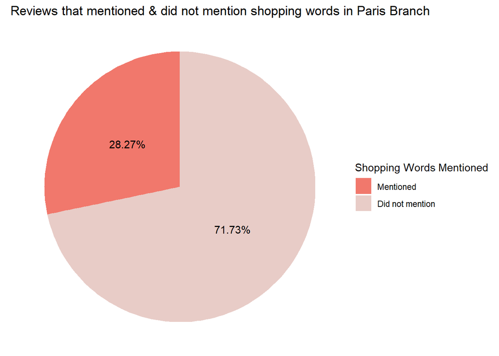

```r
p_mention_orno <- freq_all[c(1,3), 1:4]
p_mention_orno%>%
  ggplot(aes(x="", y=freq_branch_pct, fill=rides)) +
  geom_bar(stat="identity", width=1) +
  coord_polar("y", start=0) +
  labs(fill = "Shopping Words Mentioned") +
  ggtitle("Reviews that mentioned & did not mention shopping words in Paris Branch") +
  theme_void()+
  geom_text(aes(label = paste0(freq_branch_pct, "%")), position = position_stack(vjust=0.5)) +
  scale_fill_manual(values=c("#F1786C", "#E8CCC7"),
                    labels=c("Mentioned", "Did not mention"))
```

Proportions of shopping words mentioned in the branch over total number of reviews in the branch & over reviews that mentioned rides in branch

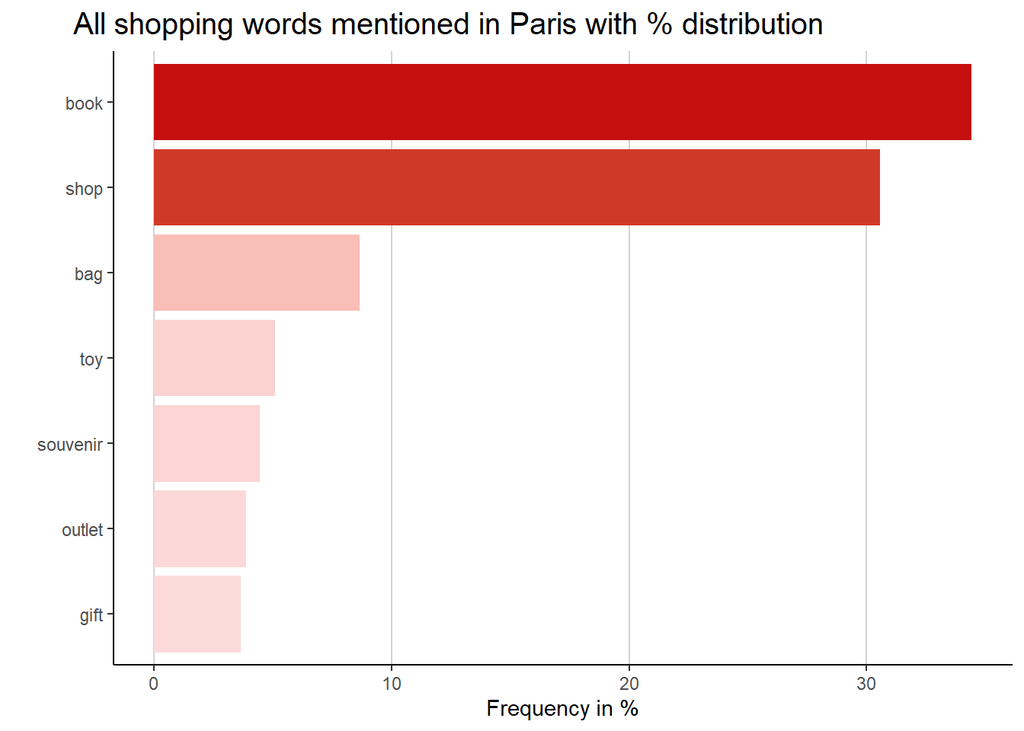

```r
p_shops <- freq_all[4:19, 1:5]

# filter freqs >= 2% of the reviews that mentioned rides in the branch, rating high to low
hot_shops <- p_shops %>%
  filter(freq_Mention_pct >= 2)

shopping_rank_plot <- hot_shops%>%
  ggplot(aes(x=reorder(rides,freq_Mention_pct),
             y=freq_Mention_pct, fill=freq_Mention_pct))+
  geom_col(position='dodge')+
  coord_flip()+
  labs(x = "", y = "Frequency in %") +
  ggtitle("All shopping words mentioned in Paris with % distribution")+
  scale_fill_gradient(low = "#FCDADA", high = "#C50F0F", guide = FALSE) +
  theme(plot.background = element_blank(),
        panel.background = element_blank(),
        panel.grid.major.x  = element_line(color = "light grey"),
        axis.line = element_line(color = "black"),
        plot.title = element_text(size = 15, hjust = -0.267, vjust = 1))

rating_rank_plot <- hot_shops %>%
  ggplot() +
  geom_col(aes(x=reorder(rides, -avg_rating), y=freq_Mention_pct, fill=freq_Mention_pct),
           width=0.7, position='dodge')+
  scale_y_continuous(name = "Frequency in %",
                     expand = c(0,0),
                     limits = c(-10, 80)) +
  geom_text(aes(x=rides, y=-5, label=avg_rating), size = 4.5) +
  labs(x = "Mostly mentioned shopping words", y = "Frequency in %") +
  ggtitle("Average rating ranked with most popular shopping words & no shopping words") +
  scale_fill_gradient(low = "#FCDADA", high = "#C50F0F", guide = FALSE)+
  labs(tag ="Ratings:")+
  theme(plot.background = element_blank(),
        panel.background = element_blank(),
        panel.grid.major.y  = element_line(color = "light grey"),
        axis.line = element_line(color = "black"),
        plot.tag.position = c(0.01,0.115),
        plot.tag = element_text(hjust = 0, size=12.5),
        plot.title = element_text(size = 15))

# grid.arrange(shopping_rank_plot, rating_rank_plot, ncol = 2)
shopping_rank_plot
```

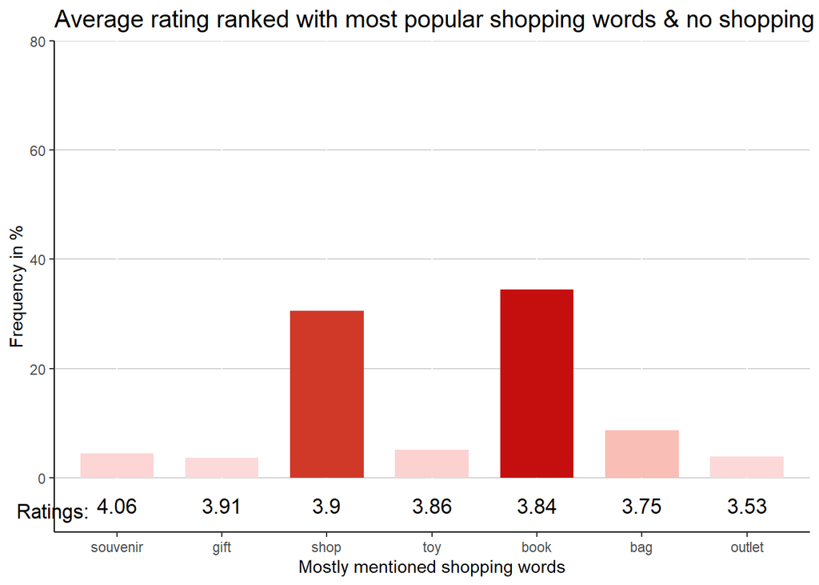

```r
rating_rank_plot
```

From the visualizations, “book” and “shop” are the leading words mentioned in the reviews, with “bag” and “toy” followed. Generally these shopping-related words received lower rating in Paris branch compared to the other two with souvenir and gift most favored by reviewers.

## Sentiment Analysis

### Hong Kong

```r
afinn = get_sentiments('afinn')
```

Integrate the three branches and attach to original dataset

```r
# rbind all 3 branches
tri_branch <- rbind(hongkong, cali, paris)
# cbind indicators to original dataset
disneyland <- cbind(disneyland, tri_branch[, 21])
colnames(disneyland)[11] <- 'if_shopping_words'
```

Distribution of sentiment scores with shopping words

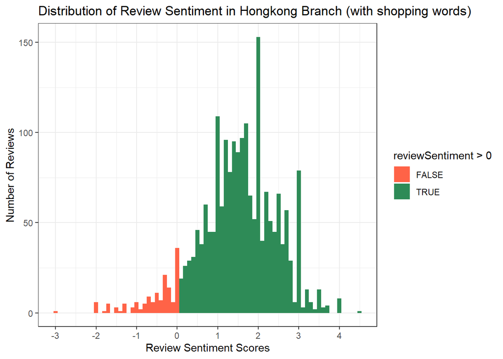

```r
dis_w_shop <- disneyland %>%
  filter(Branch == 'Disneyland_HongKong', if_shopping_words == 1) %>%
  select(Review_ID,Review_Text)%>%
  group_by(Review_ID)%>%
  unnest_tokens(output=word,input=Review_Text)%>%
  inner_join(afinn)%>%
  summarize(reviewSentiment = mean(value))%>%
  ungroup()%>%
  ggplot(aes(x=reviewSentiment,fill=reviewSentiment>0))+
  geom_histogram(binwidth = 0.1)+
  scale_x_continuous(breaks=seq(-5,5,1))+
  scale_fill_manual(values=c('tomato','seagreen'))+
  theme_bw() +
  labs(x = "Review Sentiment Scores", y = "Number of Reviews") +
  ggtitle("Distribution of Review Sentiment in Hongkong Branch (with shopping words)")
dis_w_shop
```

Distribution of sentiment scores without shopping words

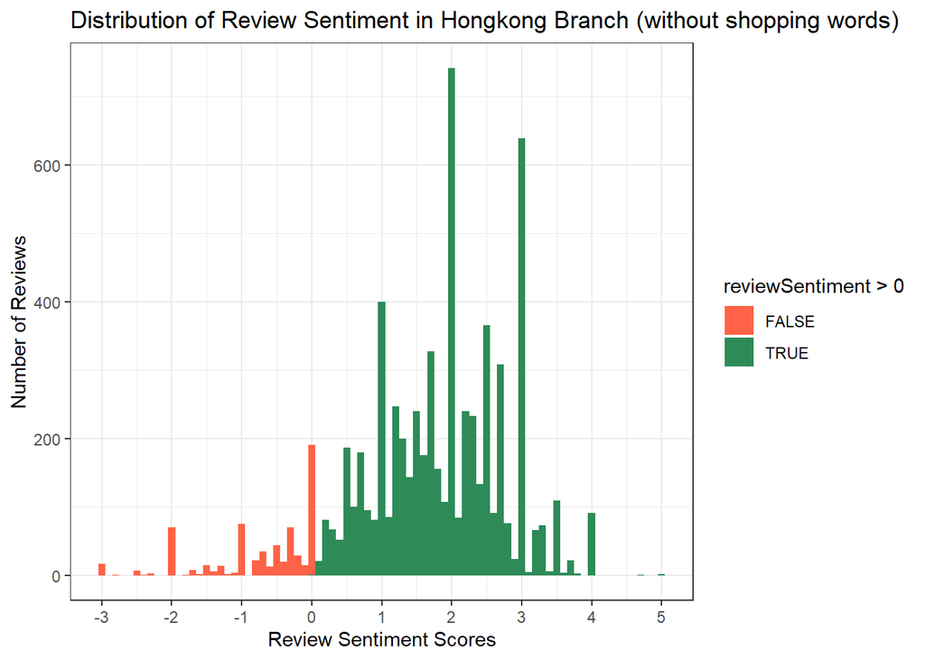

```r
dis_wt_shop <- disneyland %>%
  filter(Branch == 'Disneyland_HongKong', if_shopping_words == 0) %>%
  select(Review_ID,Review_Text)%>%
  group_by(Review_ID)%>%
  unnest_tokens(output=word,input=Review_Text)%>%
  inner_join(afinn)%>%
  summarize(reviewSentiment = mean(value))%>%
  ungroup()%>%
  ggplot(aes(x=reviewSentiment,fill=reviewSentiment>0))+
  geom_histogram(binwidth = 0.1)+
  scale_x_continuous(breaks=seq(-5,5,1))+
  scale_fill_manual(values=c('tomato','seagreen'))+
  theme_bw() +
  labs(x = "Review Sentiment Scores", y = "Number of Reviews") +
  ggtitle("Distribution of Review Sentiment in Hongkong Branch (without shopping words)")
dis_wt_shop
```

### California

Distribution of sentiment scores with shopping words

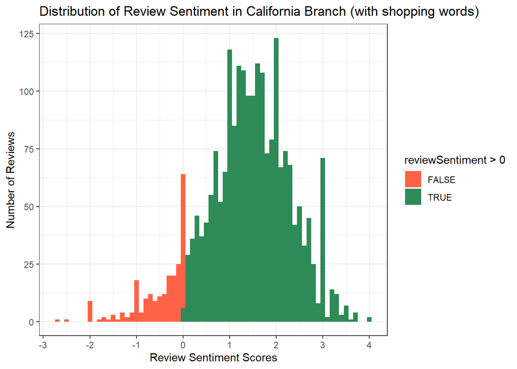

```r
dis_w_shop <- disneyland %>%
  filter(Branch == 'Disneyland_California', if_shopping_words == 1) %>%
  select(Review_ID,Review_Text)%>%
  group_by(Review_ID)%>%
  unnest_tokens(output=word,input=Review_Text)%>%
  inner_join(afinn)%>%
  summarize(reviewSentiment = mean(value))%>%
  ungroup()%>%
  ggplot(aes(x=reviewSentiment,fill=reviewSentiment>0))+
  geom_histogram(binwidth = 0.1)+
  scale_x_continuous(breaks=seq(-5,5,1))+
  scale_fill_manual(values=c('tomato','seagreen'))+
  theme_bw() +
  labs(x = "Review Sentiment Scores", y = "Number of Reviews") +
  ggtitle("Distribution of Review Sentiment in California Branch (with shopping words)")
dis_w_shop
```

Distribution of sentiment scores without shopping words

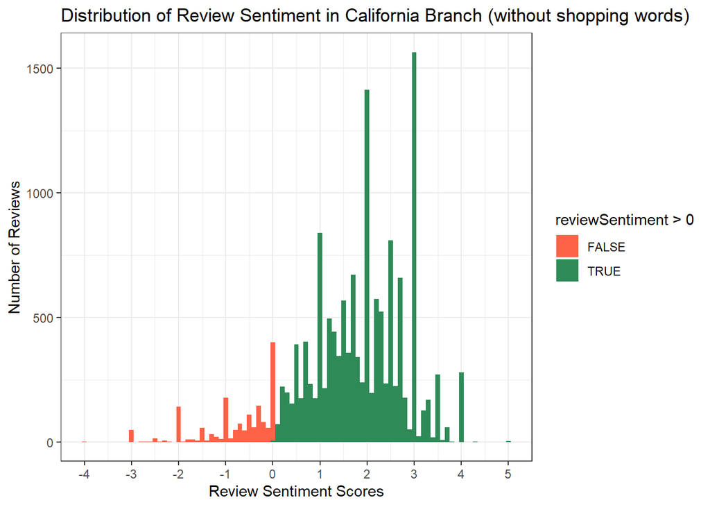

```r
dis_wt_shop <- disneyland %>%
  filter(Branch == 'Disneyland_California', if_shopping_words == 0) %>%
  select(Review_ID,Review_Text)%>%
  group_by(Review_ID)%>%
  unnest_tokens(output=word,input=Review_Text)%>%
  inner_join(afinn)%>%
  summarize(reviewSentiment = mean(value))%>%
  ungroup()%>%
  ggplot(aes(x=reviewSentiment,fill=reviewSentiment>0))+
  geom_histogram(binwidth = 0.1)+
  scale_x_continuous(breaks=seq(-5,5,1))+
  scale_fill_manual(values=c('tomato','seagreen'))+
  theme_bw() +
  labs(x = "Review Sentiment Scores", y = "Number of Reviews") +
  ggtitle("Distribution of Review Sentiment in California Branch (without shopping words)")
dis_wt_shop
```

### Paris

Distribution of sentiment scores with shopping words

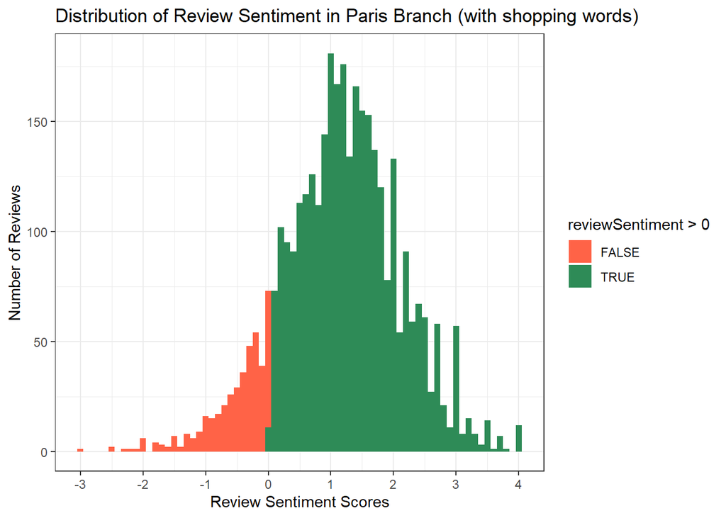

```r
dis_w_shop <- disneyland %>%
  filter(Branch == 'Disneyland_Paris', if_shopping_words == 1) %>%
  select(Review_ID,Review_Text)%>%
  group_by(Review_ID)%>%
  unnest_tokens(output=word,input=Review_Text)%>%
  inner_join(afinn)%>%
  summarize(reviewSentiment = mean(value))%>%
  ungroup()%>%
  ggplot(aes(x=reviewSentiment,fill=reviewSentiment>0))+
  geom_histogram(binwidth = 0.1)+
  scale_x_continuous(breaks=seq(-5,5,1))+
  scale_fill_manual(values=c('tomato','seagreen'))+
  theme_bw() +
  labs(x = "Review Sentiment Scores", y = "Number of Reviews") +
  ggtitle("Distribution of Review Sentiment in Paris Branch (with shopping words)")
dis_w_shop
```

Distribution of sentiment scores without shopping words

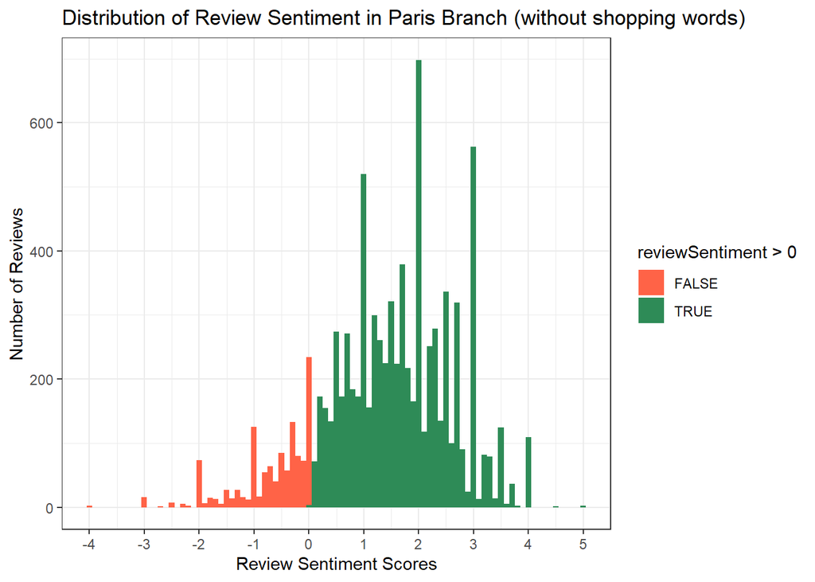

```r
dis_wt_shop <- disneyland %>%
  filter(Branch == 'Disneyland_Paris', if_shopping_words == 0) %>%
  select(Review_ID,Review_Text)%>%
  group_by(Review_ID)%>%
  unnest_tokens(output=word,input=Review_Text)%>%
  inner_join(afinn)%>%
  summarize(reviewSentiment = mean(value))%>%
  ungroup()%>%
  ggplot(aes(x=reviewSentiment,fill=reviewSentiment>0))+
  geom_histogram(binwidth = 0.1)+
  scale_x_continuous(breaks=seq(-5,5,1))+
  scale_fill_manual(values=c('tomato','seagreen'))+
  theme_bw() +
  labs(x = "Review Sentiment Scores", y = "Number of Reviews") +
  ggtitle("Distribution of Review Sentiment in Paris Branch (without shopping words)")
dis_wt_shop
```

## Overall Sentiment Analytis

Calculate proportions and average scores required

```r
##### hong kong#####
# proportion of positive sentiment with shopping words
pos_prop_w_shop_hk <- disneyland %>%
  filter(Branch == 'Disneyland_HongKong', if_shopping_words == 1) %>%
  select(Review_ID,Review_Text)%>%
  group_by(Review_ID)%>%
  unnest_tokens(output=word,input=Review_Text)%>%
  inner_join(afinn) %>%
  ungroup() %>%
  mutate(positive = ifelse(value >= 0, 1, 0)) %>%
  summarize(proportion_positive = sum(positive) / n())

#  proportion of positive sentiment without shopping words
pos_prop_wt_shop_hk <- disneyland %>%
  filter(Branch == 'Disneyland_HongKong', if_shopping_words == 0) %>%
  select(Review_ID,Review_Text)%>%
  group_by(Review_ID)%>%
  unnest_tokens(output=word,input=Review_Text)%>%
  inner_join(afinn) %>%
  ungroup() %>%
  mutate(positive = ifelse(value >= 0, 1, 0)) %>%
  summarize(proportion_positive = sum(positive) / n())

# average sentiment score with shopping words
mean_w_shop_hk <- disneyland %>%
  filter(Branch == 'Disneyland_HongKong', if_shopping_words == 1) %>%
  select(Review_ID,Review_Text)%>%
  group_by(Review_ID)%>%
  unnest_tokens(output=word,input=Review_Text)%>%
  inner_join(afinn) %>%
  ungroup() %>%
  summarize(avg = mean(value))

# average sentiment score without shopping words
mean_wt_shop_hk <- disneyland %>%
  filter(Branch == 'Disneyland_HongKong', if_shopping_words == 0) %>%
  select(Review_ID,Review_Text)%>%
  group_by(Review_ID)%>%
  unnest_tokens(output=word,input=Review_Text)%>%
  inner_join(afinn) %>%
  ungroup() %>%
  summarize(avg = mean(value))


##### california #####
# proportion of positive sentiment with shopping words
pos_prop_w_shop_ca <- disneyland %>%
  filter(Branch == 'Disneyland_California', if_shopping_words == 1) %>%
  select(Review_ID,Review_Text)%>%
  group_by(Review_ID)%>%
  unnest_tokens(output=word,input=Review_Text)%>%
  inner_join(afinn) %>%
  ungroup() %>%
  mutate(positive = ifelse(value >= 0, 1, 0)) %>%
  summarize(proportion_positive = sum(positive) / n())

#  proportion of positive sentiment without shopping words
pos_prop_wt_shop_ca <- disneyland %>%
  filter(Branch == 'Disneyland_California', if_shopping_words == 0) %>%
  select(Review_ID,Review_Text)%>%
  group_by(Review_ID)%>%
  unnest_tokens(output=word,input=Review_Text)%>%
  inner_join(afinn) %>%
  ungroup() %>%
  mutate(positive = ifelse(value >= 0, 1, 0)) %>%
  summarize(proportion_positive = sum(positive) / n())

# average sentiment score with shopping words
mean_w_shop_ca <- disneyland %>%
  filter(Branch == 'Disneyland_California', if_shopping_words == 1) %>%
  select(Review_ID,Review_Text)%>%
  group_by(Review_ID)%>%
  unnest_tokens(output=word,input=Review_Text)%>%
  inner_join(afinn) %>%
  ungroup() %>%
  summarize(avg = mean(value))

# average sentiment score without shopping words
mean_wt_shop_ca <- disneyland %>%
  filter(Branch == 'Disneyland_California', if_shopping_words == 0) %>%
  select(Review_ID,Review_Text)%>%
  group_by(Review_ID)%>%
  unnest_tokens(output=word,input=Review_Text)%>%
  inner_join(afinn) %>%
  ungroup() %>%
  summarize(avg = mean(value))



##### paris #####
# proportion of positive sentiment with shopping words
pos_prop_w_shop_paris <- disneyland %>%
  filter(Branch == 'Disneyland_Paris', if_shopping_words == 1) %>%
  select(Review_ID,Review_Text)%>%
  group_by(Review_ID)%>%
  unnest_tokens(output=word,input=Review_Text)%>%
  inner_join(afinn) %>%
  ungroup() %>%
  mutate(positive = ifelse(value >= 0, 1, 0)) %>%
  summarize(proportion_positive = sum(positive) / n())

#  proportion of positive sentiment without shopping words
pos_prop_wt_shop_paris <- disneyland %>%
  filter(Branch == 'Disneyland_Paris', if_shopping_words == 0) %>%
  select(Review_ID,Review_Text)%>%
  group_by(Review_ID)%>%
  unnest_tokens(output=word,input=Review_Text)%>%
  inner_join(afinn) %>%
  ungroup() %>%
  mutate(positive = ifelse(value >= 0, 1, 0)) %>%
  summarize(proportion_positive = sum(positive) / n())

# average sentiment score with shopping words
mean_w_shop_paris <- disneyland %>%
  filter(Branch == 'Disneyland_Paris', if_shopping_words == 1) %>%
  select(Review_ID,Review_Text)%>%
  group_by(Review_ID)%>%
  unnest_tokens(output=word,input=Review_Text)%>%
  inner_join(afinn) %>%
  ungroup() %>%
  summarize(avg = mean(value))

# average sentiment score without shopping words
mean_wt_shop_paris <- disneyland %>%
  filter(Branch == 'Disneyland_Paris', if_shopping_words == 0) %>%
  select(Review_ID,Review_Text)%>%
  group_by(Review_ID)%>%
  unnest_tokens(output=word,input=Review_Text)%>%
  inner_join(afinn) %>%
  ungroup() %>%
  summarize(avg = mean(value))
```

Proportion of positive words in reviews w/wt shopping words

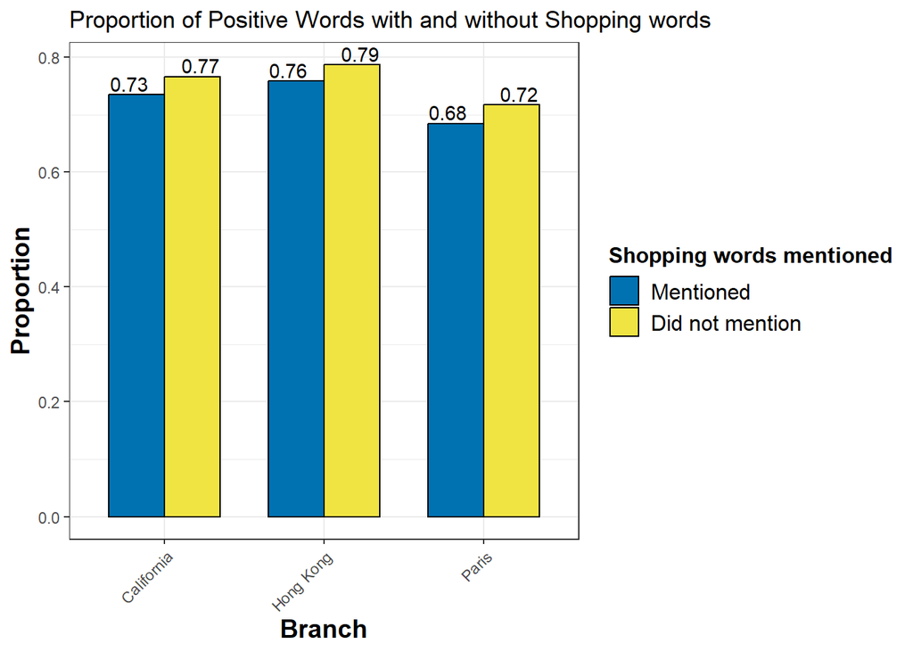

```r
# make proportion plot
df_prop = data.frame(branch = c('Hong Kong', 'California', 'Paris'),
                     prop_pos_words_w_shop = c(as.numeric(pos_prop_w_shop_hk), as.numeric(pos_prop_w_shop_ca), as.numeric(pos_prop_w_shop_paris)),
                     prop_pos_words_wt_shop = c(as.numeric(pos_prop_wt_shop_hk), as.numeric(pos_prop_wt_shop_ca), as.numeric(pos_prop_wt_shop_paris)))
df_prop_long <- tidyr::pivot_longer(df_prop, cols = c("prop_pos_words_w_shop", "prop_pos_words_wt_shop"), names_to = "category", values_to = "proportion")
ggplot(df_prop_long, aes(x = branch, y = proportion, fill = category)) +
  geom_bar(stat = "identity", position = "dodge", width = 0.7, color = "black", size = 0.5) +
  scale_fill_manual(values = c("#0072B2", "#F0E442"),
                    labels=c("Mentioned", "Did not mention")) +
  labs(title = "Proportion of Positive Words with and without Shopping words", x = "Branch", y = "Proportion", fill = 'Shopping words mentioned') +
  geom_text(aes(label=round(proportion, 2)), position=position_dodge(width=0.9), vjust=-0.25) +
theme_bw() +
  theme(axis.text.x = element_text(angle = 45, hjust = 1),
        axis.title = element_text(size = 14, face = "bold"),
        legend.title = element_text(size = 12, face = "bold"),
        legend.text = element_text(size = 12))
```

Average sentiment scores of reviews w/wt shopping words

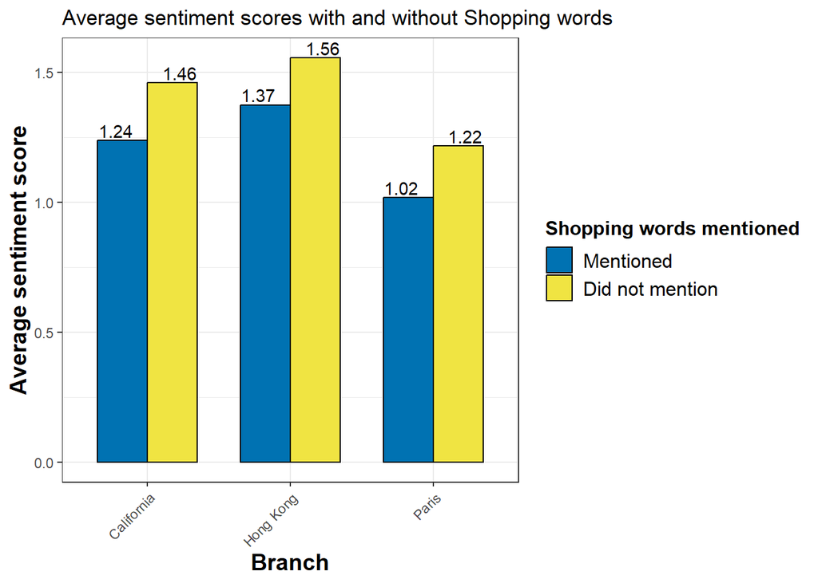

```r
# make average score plot
df_mean = data.frame(branch = c('Hong Kong', 'California', 'Paris'),
                     mean_w_shop = c(as.numeric(mean_w_shop_hk), as.numeric(mean_w_shop_ca), as.numeric(mean_w_shop_paris)),
                     mean_wt_shop = c(as.numeric(mean_wt_shop_hk), as.numeric(mean_wt_shop_ca), as.numeric(mean_wt_shop_paris)))
df_mean_long <- tidyr::pivot_longer(df_mean, cols = c("mean_w_shop", "mean_wt_shop"), names_to = "category", values_to = "proportion")
ggplot(df_mean_long, aes(x = branch, y = proportion, fill = category)) +
  geom_bar(stat = "identity", position = "dodge", width = 0.7, color = "black", size = 0.5) +
  scale_fill_manual(values = c("#0072B2", "#F0E442"),
                    labels=c("Mentioned", "Did not mention")) +
  labs(title = "Average sentiment scores with and without Shopping words", x = "Branch", y = "Average sentiment score", fill = 'Shopping words mentioned') +
  geom_text(aes(label=round(proportion, 2)), position=position_dodge(width=0.9), vjust=-0.25) +
theme_bw() +
  theme(axis.text.x = element_text(angle = 45, hjust = 1),
        axis.title = element_text(size = 14, face = "bold"),
        legend.title = element_text(size = 12, face = "bold"),
        legend.text = element_text(size = 12))
```

From the proportion and average sentiment score graphs presented above, we observe that among all 3 branches, more positive words are in reviews unrelated to shopping experience, and reviews unrelated to shopping experience tend to have more positive tone than reviews that talked about shopping. We can thus conclude that it might be a common problem that Disneyland as a whole has to do better in improving travelers’ shopping experience.